# Cuestionario de Monitoreo Post Entrega Tarjetas/Bonos

## Informe de Indicadores

### 1. Comprensión de la población participante sobre el proceso "Canje de cupón", en porcentaje

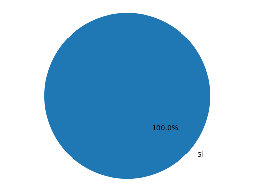

```python
import matplotlib.pyplot as plt

labels = ['Sí']
sizes = [100]

plt.pie(sizes, labels=labels, autopct='%1.1f%%', startangle=140)

plt.axis('equal')
plt.show()
```

Se puede visualizar que del total de los encuestados, el 100% comprende el proceso del canje del cupón.

### 2. Conocimiento de la población sobre el valor del cupón por entrega, en porcentaje

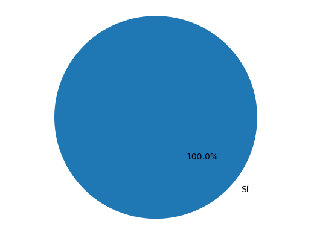

```python
labels = ['Sí']
sizes = [100]

plt.pie(sizes, labels=labels, autopct='%1.1f%%', startangle=140)

plt.axis('equal')  # Equal aspect ratio ensures that pie is drawn as a circle.
plt.show()
```

```python
Los entrevistados en su totalidad manifiestan que conocen el valor del cupón por entrega.
```

### 3. Canje de los cupones según localidad

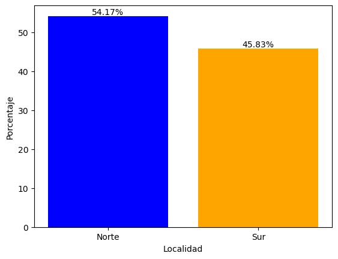

```python
import matplotlib.pyplot as plt

regiones = ['Norte', 'Sur']
porcentajes = [54.17, 45.83]

plt.bar(regiones, porcentajes, color=['blue', 'orange'])

for i in range(len(regiones)):
    plt.text(regiones[i], porcentajes[i], f"{porcentajes[i]:.2f}%", ha='center', va='bottom')

plt.xlabel('Localidad')
plt.ylabel('Porcentaje')

plt.show()
```

Existe un mayor canje en la localidad Norte, correspondiente a Ecuabastos.

### 4. Servicio al cliente: ¿Lo trataron igual que a los clientes que no eran parte del proyecto?

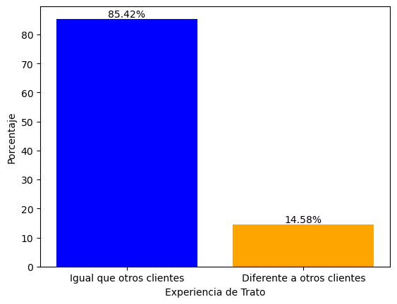

```python
import matplotlib.pyplot as plt

porcentajes = [85.42, 14.58]
regiones = ['Igual que otros clientes', 'Diferente a otros clientes']

plt.bar(regiones, porcentajes, color=['blue', 'orange'])

for i in range(len(regiones)):
    plt.text(regiones[i], porcentajes[i], f"{porcentajes[i]:.2f}%", ha='center', va='bottom')

plt.xlabel('Experiencia de Trato')
plt.ylabel('Porcentaje')

plt.show()
```

### 5. Perspectivas de la población sobre su experiencia de "Servicio al Cliente"

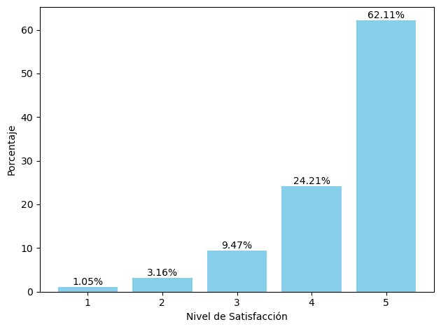

```python
import matplotlib.pyplot as plt

categorias = ['1', '2', '3', '4', '5']
porcentajes = [1.05, 3.16, 9.47, 24.21, 62.11]

plt.bar(categorias, porcentajes, color='skyblue')

for i in range(len(categorias)):
    plt.text(categorias[i], porcentajes[i], f"{porcentajes[i]:.2f}%", ha='center', va='bottom')

plt.xlabel('Nivel de Satisfacción')
plt.ylabel('Porcentaje')

plt.tight_layout()
plt.show()
```

Nota: 1= Muy insatisfecho/a ; 2= Insatisfecho/a ; 3= Ni satisfecho ni insatisfecho ; 4= Satisfecho ; 5= Muy satisfecho

### 6. Satisfacción con el proceso de selección de las familias beneficiadas

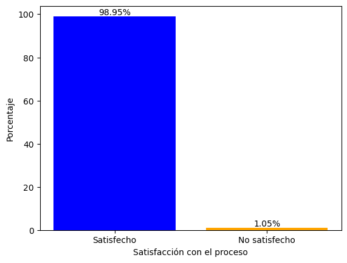

```python
import matplotlib.pyplot as plt

porcentajes = [98.95, 1.05]
regiones = ['Satisfecho', 'No satisfecho']

plt.bar(regiones, porcentajes, color=['blue', 'orange'])

for i in range(len(regiones)):
    plt.text(regiones[i], porcentajes[i], f"{porcentajes[i]:.2f}%", ha='center', va='bottom')

plt.xlabel('Satisfacción con el proceso')
plt.ylabel('Porcentaje')

plt.show()
```

El 98,95 % de la población indica estar satisfecho con la selección de las familias atendidas.

### 7. Grado de satisfacción con la ayuda humanitaria

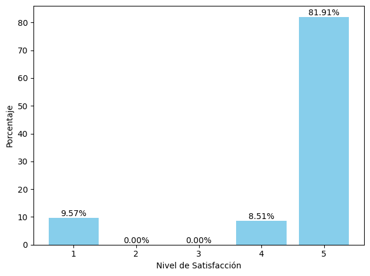

```python
import matplotlib.pyplot as plt

categorias = ['1', '2', '3', '4', '5']
porcentajes = [9.57, 0, 0, 8.51, 81.91]

plt.bar(categorias, porcentajes, color='skyblue')

for i in range(len(categorias)):
    plt.text(categorias[i], porcentajes[i], f"{porcentajes[i]:.2f}%", ha='center', va='bottom')

plt.xlabel('Nivel de Satisfacción')
plt.ylabel('Porcentaje')

plt.tight_layout()
plt.show()
```

Nota: 1= Muy insatisfecho/a ; 2= Insatisfecho/a ; 3= Ni satisfecho ni insatisfecho ; 4= Satisfecho ; 5= Muy satisfecho

El 90,42 % está satisfecho y muy satisfecho con la asistencia humanitaria